# Kiểm định mô hình định giá tài sản vốn (CAPM) trên dữ liệu Fama-French

**Nhóm thực hiện**

1. Lê Xuân Trí
2. Bùi Lê Bảo Ngọc
3. Đinh Dương Huy
4. Phạm Thái Sơn

## 0. Tổng quan: câu hỏi cốt lõi và các giai đoạn của bài nghiên cứu

Bài này kiểm định mô hình định giá tài sản vốn (CAPM) trên bộ dữ liệu Fama-French. Câu hỏi nhóm em muốn trả lời gồm hai ý: lợi suất vượt trội của thị trường giải thích được bao nhiêu lợi suất của các danh mục khác, và phần lợi suất còn lại (alpha) có thật sự bằng 0 như CAPM dự đoán hay không.

**Giới hạn quan trọng của dữ liệu.** File chỉ chứa bốn chuỗi: `Mkt-RF`, `SMB`, `HML` và `RF`. Không có lợi suất của từng cổ phiếu hay danh mục ngành. Vì vậy nhóm em dùng `SMB` và `HML` làm hai tài sản kiểm định, còn `Mkt-RF` là biến giải thích. Đây là cách hợp lệ về mặt kỹ thuật vì hai chuỗi này là lợi suất của các danh mục đầu tư không tốn vốn (mua một nhóm, bán một nhóm), tức đã là lợi suất vượt trội. Kết quả vì thế trả lời câu hỏi "beta thị trường có giải thích được phần bù quy mô và phần bù giá trị không", chưa phải beta của một cổ phiếu cụ thể. Code ở bên dưới viết sao cho có thể thay tài sản kiểm định bằng lợi suất cổ phiếu hay danh mục khác khi có dữ liệu.

Bài đi theo tám giai đoạn như file mẫu về hồi quy đa biến: (1) lý thuyết và giả thuyết, (2) làm sạch dữ liệu, (3) thống kê mô tả và trực quan hóa, (4) ước lượng mô hình, (5) diễn giải và kiểm định giả thuyết, (6) chẩn đoán khuyết tật, (7) kiểm tra độ bền vững, (8) thảo luận hạn chế và hướng mở rộng.

## 1. Cơ sở lý thuyết, câu hỏi nghiên cứu và giả thuyết

### 1.1 Nền tảng lý thuyết: mô hình CAPM

CAPM (Sharpe, 1964; Lintner, 1965; Mossin, 1966) cho rằng trong thị trường cân bằng, lợi suất kỳ vọng vượt trội của một tài sản chỉ phụ thuộc vào rủi ro hệ thống của nó, đo bằng beta:

E(R<sub>i</sub>) − R<sub>f</sub> = β<sub>i</sub> [E(R<sub>m</sub>) − R<sub>f</sub>], β<sub>i</sub> = Cov(R<sub>i</sub>, R<sub>m</sub>) / Var(R<sub>m</sub>)

Phương trình này đúng khi nhà đầu tư ưa thích trung bình và phương sai, có kỳ vọng đồng nhất, vay và cho vay được ở lãi suất phi rủi ro *R<sub>f</sub>*, và thị trường không có ma sát. Đường biểu diễn quan hệ tuyến tính giữa lợi suất kỳ vọng và beta gọi là đường thị trường chứng khoán (SML).

### 1.2 Mô hình kiểm định

Theo hướng chuỗi thời gian của Black, Jensen và Scholes (1972), nhóm em hồi quy lợi suất vượt trội của từng tài sản lên lợi suất vượt trội của thị trường:

R<sub>i,t</sub> − R<sub>f,t</sub> = α<sub>i</sub> + β<sub>i</sub> (R<sub>m,t</sub> − R<sub>f,t</sub>) + ε<sub>i,t</sub>

CAPM hàm ý α<sub>i</sub> = 0 với mọi tài sản. Do `SMB` và `HML` đã là lợi suất vượt trội (danh mục không tốn vốn) nên ta hồi quy trực tiếp mà không cần trừ thêm `RF`.

### 1.3 Câu hỏi nghiên cứu

- Q1. Phần bù rủi ro thị trường có dương và có ý nghĩa thống kê không?
- Q2. Beta thị trường của SMB và HML bằng bao nhiêu, và có ổn định theo thời gian không?
- Q3. CAPM có giải thích được lợi suất của SMB và HML không, tức alpha có bằng 0 không?
- Q4. Các kết luận có bền vững khi đổi mẫu và đặc tả không?

### 1.4 Hệ thống giả thuyết

- H1: E(R<sub>m</sub> − R<sub>f</sub>) > 0.
- H2: α<sub>SMB</sub> = 0.
- H3: α<sub>HML</sub> = 0.
- H4 (GRS): α<sub>SMB</sub> = α<sub>HML</sub> = 0 đồng thời.
- H5: alpha và beta không đổi giữa các giai đoạn (kiểm định Chow).
- H6: quan hệ tuyến tính, tức hệ số của bình phương lợi suất thị trường bằng 0 (Treynor-Mazuy).

## 2. Dữ liệu thực nghiệm và quy trình tiền xử lý

### 2.1 Nguồn dữ liệu và nạp dữ liệu

Hàm đọc file tự tìm hai dòng tiêu đề `,Mkt-RF,SMB,HML,RF` để tách khối tháng và khối năm, thay vì cố định số dòng bỏ qua. Cách này vẫn chạy được khi Fama-French cập nhật thêm tháng mới.

```python
import pandas as pd, numpy as np
import matplotlib.pyplot as plt
import seaborn as sns
from scipy import stats

sns.set_theme(style="whitegrid")
PATH = "F-F_Research_Data_Factors_1.csv"
lines = open(PATH, encoding="utf-8", errors="ignore").read().splitlines()

# File gồm vài dòng ghi chú, khối dữ liệu THÁNG, rồi khối dữ liệu NĂM
hdr = [i for i, l in enumerate(lines) if l.strip().startswith(",Mkt-RF")]

def read_block(i):
    rows = []
    for l in lines[i + 1:]:
        if not l.strip():
            break
        rows.append([x.strip() for x in l.split(",")])
    d = pd.DataFrame(rows, columns=["period", "MktRF", "SMB", "HML", "RF"])
    return d.apply(pd.to_numeric, errors="coerce")

m_raw, a_raw = read_block(hdr[0]), read_block(hdr[1])

print("Ghi chú đầu file:")
print("\n".join(l.strip() for l in lines[:3]))
print("\nKhối tháng:", m_raw.shape, "| khối năm:", a_raw.shape)
print("\n5 dòng đầu:");  print(m_raw.head().to_string(index=False))
print("\n5 dòng cuối:"); print(m_raw.tail().to_string(index=False))
```

Kết quả chạy Python

```
Ghi chú đầu file:
This file was created using the 202609 CRSP database.
The 1-month TBill rate data until 202405 are from Ibbotson Associates. Starting from 202406, the 1-month TBill rate is from ICE BofA US 1-Month Treasury Bill Index.
The annual TBill return is compounded from the monthly T-bill rates from January to December.

Khối tháng: (1203, 5) | khối năm: (99, 5)

5 dòng đầu:
 period  MktRF   SMB   HML   RF
 192607   2.89 -2.42 -2.75 0.22
 192608   2.64 -1.44  4.13 0.25
 192609   0.38 -1.36  0.05 0.23
 192610  -3.27 -0.18  0.78 0.32
 192611   2.54 -0.17 -0.48 0.31

5 dòng cuối:
 period  MktRF   SMB   HML   RF
 202605   4.91 -1.59 -2.31 0.31
 202606  -1.07  3.39  3.58 0.29
 202607  -0.61 -1.92  2.11 0.33
 202608   2.56  0.34 -3.54 0.29
 202609  -1.07 -3.16 -1.55 0.31
```

**Nhận xét:** Khối tháng có 1.203 dòng (07/1926 đến 09/2026) và khối năm có 99 dòng (1927 đến 2025). Cột đầu của file không có tên nên nhóm em đặt là `period`.

### 2.2 Từ điển biến

File gốc có hai khối: khối dữ liệu tháng từ 07/1926 đến 09/2026 và khối dữ liệu năm. Mọi giá trị tính theo phần trăm. Theo ghi chú đầu file, lãi suất tín phiếu 1 tháng đến 05/2024 lấy từ Ibbotson Associates, từ 06/2024 lấy từ chỉ số ICE BofA US 1-Month Treasury Bill.

| Biến | Ý nghĩa | Loại |
| --- | --- | --- |
| `period` | Kỳ (năm và tháng, dạng YYYYMM) | Thời gian |
| `MktRF` (Mkt-RF) | Lợi suất vượt trội của thị trường (cổ phiếu Mỹ trong CRSP, bình quân gia quyền theo giá trị thị trường, trừ lãi suất tín phiếu 1 tháng), %/tháng | Liên tục |
| `SMB` | Small Minus Big: lợi suất danh mục cổ phiếu quy mô nhỏ trừ danh mục quy mô lớn, %/tháng | Liên tục |
| `HML` | High Minus Low: lợi suất danh mục cổ phiếu có tỷ số giá trị sổ sách trên giá thị trường cao trừ danh mục thấp, %/tháng | Liên tục |
| `RF` | Lãi suất tín phiếu kho bạc 1 tháng, %/tháng | Liên tục |
| `Rm` | Lợi suất thị trường chưa trừ lãi phi rủi ro = MktRF + RF (nhóm em tạo) | Liên tục |
| `lRm`, `lRF`, `lMktRF` | Lợi suất dạng log, tính bằng 100 × ln(1 + R/100) (nhóm em tạo) | Liên tục |
| `MktRF2`, `MktRF_lag1` | Bình phương và trễ 1 tháng của MktRF, dùng cho kiểm định phi tuyến và hiệu chỉnh Dimson | Liên tục |
| `post1963`, `decade` | Biến giả mẫu từ 07/1963 và thập niên | Nhị phân, rời rạc |
| `crisis` | Bằng 1 nếu tháng thuộc năm giai đoạn biến động lớn do nhóm em tự định nghĩa | Nhị phân |
| `cum_*`, `drawdown_Rm`, `vol12_MktRF` | Giá trị tích lũy của 1 USD, mức sụt giảm so với đỉnh, độ lệch chuẩn trượt 12 tháng quy năm | Liên tục |
| `out_*` | Cờ ngoại lai \|z\| > 3 | Nhị phân |

### 2.3 Kiểm tra chất lượng dữ liệu và làm sạch

Nhóm em kiểm tra sáu thứ: giá trị thiếu và mã thiếu, trùng lặp, tính liên tục của chuỗi thời gian, miền giá trị hợp lý, đối chiếu khối tháng với khối năm trong cùng file, và ngoại lai. Riêng điểm (e) là phép kiểm tra nội bộ khá chặt: cộng dồn (compound) 12 tháng phải khớp với số liệu năm.

```python
m = m_raw.copy()

# (a) Giá trị thiếu. Dữ liệu Fama-French mã hóa thiếu bằng -99.99 hoặc -999
print("(a) NaN:", int(m.isna().sum().sum()),
      "| mã thiếu (<= -99):", int((m.drop(columns="period") <= -99).sum().sum()))

# (b) Trùng lặp
print("(b) Kỳ bị trùng:", int(m.period.duplicated().sum()))

# (c) Chuỗi thời gian có liên tục không?
m["date"] = pd.to_datetime(m.period.astype(int).astype(str), format="%Y%m") + pd.offsets.MonthEnd(0)
full = pd.period_range(m.date.min().to_period("M"), m.date.max().to_period("M"), freq="M")
missing_months = full.difference(m.date.dt.to_period("M"))
print(f"(c) {len(m)} tháng, kỳ vọng {len(full)}, thiếu {len(missing_months)} tháng "
      f"({m.date.min():%m/%Y} đến {m.date.max():%m/%Y})")

# (d) Miền giá trị hợp lý
print("(d) Số tháng có RF < 0:", int((m.RF < 0).sum()))
print(m[["MktRF", "SMB", "HML", "RF"]].agg(["min", "max"]).T.to_string())

# (e) Đối chiếu với khối dữ liệu NĂM trong cùng file
m["Rm"] = m.MktRF + m.RF
yr = m.groupby(m.date.dt.year)
chk = pd.DataFrame({"n": yr.size(),
                    "Rm_c": yr.Rm.apply(lambda s: (np.prod(1 + s / 100) - 1) * 100),
                    "RF_c": yr.RF.apply(lambda s: (np.prod(1 + s / 100) - 1) * 100)})
chk["MktRF_c"] = chk.Rm_c - chk.RF_c
a = a_raw.set_index("period")
ok = chk.index[(chk.n == 12) & chk.index.isin(a.index)]
d_mkt = (chk.loc[ok, "MktRF_c"] - a.loc[ok, "MktRF"]).abs()
d_rf = (chk.loc[ok, "RF_c"] - a.loc[ok, "RF"]).abs()
print(f"(e) Đối chiếu {len(ok)} năm đủ 12 tháng: lệch tối đa Mkt-RF = {d_mkt.max():.3f}, "
      f"RF = {d_rf.max():.3f} (điểm phần trăm)")

# (f) Ngoại lai theo z-score: chỉ báo cáo, KHÔNG xóa (đây là các cú sốc thật của thị trường)
cols = ["MktRF", "SMB", "HML", "RF"]
z = (m[cols] - m[cols].mean()) / m[cols].std()
print("(f) Số tháng có |z| > 3:", (z.abs() > 3).sum().to_dict())
print("\n5 tháng tệ nhất của Mkt-RF:");  print(m.nsmallest(5, "MktRF")[["date", "MktRF"]].to_string(index=False))
print("\n5 tháng tốt nhất của Mkt-RF:"); print(m.nlargest(5, "MktRF")[["date", "MktRF"]].to_string(index=False))
```

Kết quả chạy Python

```
(a) NaN: 0 | mã thiếu (<= -99): 0
(b) Kỳ bị trùng: 0
(c) 1203 tháng, kỳ vọng 1203, thiếu 0 tháng (07/1926 đến 09/2026)
(d) Số tháng có RF < 0: 12
         min    max
MktRF -28.74  38.81
SMB   -17.39  35.96
HML   -13.83  35.52
RF     -0.06   1.35
(e) Đối chiếu 99 năm đủ 12 tháng: lệch tối đa Mkt-RF = 0.041, RF = 0.030 (điểm phần trăm)
(f) Số tháng có |z| > 3: {'MktRF': 17, 'SMB': 11, 'HML': 18, 'RF': 17}

5 tháng tệ nhất của Mkt-RF:
      date  MktRF
1931-09-30 -28.74
1938-03-31 -23.91
1987-10-31 -23.19
1940-05-31 -22.00
1932-05-31 -20.51

5 tháng tốt nhất của Mkt-RF:
      date  MktRF
1933-04-30  38.81
1932-08-31  37.12
1932-07-31  33.61
1938-06-30  23.89
1933-05-31  21.43
```

**Nhận xét:** Dữ liệu rất sạch: không có giá trị thiếu, không có mã thiếu (-99,99 hay -999), không trùng, và đủ 1.203 tháng liên tục. Có 12 tháng `RF` hơi âm (nhỏ nhất -0,06), tất cả rơi vào giai đoạn 1933 đến 1941, khi lãi suất tín phiếu gần bằng 0, nên nhóm em giữ nguyên. Khi cộng dồn 12 tháng, số liệu khớp với khối năm cho 99 năm đủ dữ liệu, lệch tối đa 0,041 điểm phần trăm với Mkt-RF và 0,030 với RF, nguyên nhân là làm tròn hai chữ số thập phân. Có 17 tháng với Mkt-RF, 11 tháng với SMB và 18 tháng với HML có |z| > 3. Đó là các cú sốc có thật (tháng tệ nhất là 09/1931 với -28,74%, tháng tốt nhất là 04/1933 với +38,81%) nên nhóm em chỉ gắn cờ `out_*`, không xóa. Xóa chúng là cách làm sai trong tài chính vì chính các tháng này tạo ra rủi ro mà CAPM muốn đo.

### 2.4 Kỹ thuật tạo biến và xuất dữ liệu sạch

Nhóm em tạo lợi suất dạng log, bình phương và trễ của Mkt-RF (cho các kiểm định mở rộng), biến giả mẫu từ 07/1963 (mốc mẫu chuẩn của Fama-French), cờ giai đoạn biến động lớn, giá trị tích lũy và mức sụt giảm của thị trường. Năm giai đoạn biến động lớn do nhóm em tự định nghĩa theo mốc thời gian thường được nhắc tới, không phải mốc chính thức của một tổ chức nào.

```python
capm = m.drop(columns="period").set_index("date")[["MktRF", "SMB", "HML", "RF"]].copy()

# Lợi suất thị trường (chưa trừ lãi suất phi rủi ro) và dạng log
capm["Rm"]     = capm.MktRF + capm.RF
capm["lRm"]    = np.log1p(capm.Rm / 100) * 100
capm["lRF"]    = np.log1p(capm.RF / 100) * 100
capm["lMktRF"] = capm.lRm - capm.lRF

# Biến phục vụ mô hình mở rộng và kiểm tra khuyết tật
capm["MktRF2"]      = capm.MktRF ** 2                  # kiểm tra phi tuyến (Treynor-Mazuy)
capm["MktRF_lag1"]  = capm.MktRF.shift(1)              # hiệu chỉnh Dimson (giao dịch không đồng bộ)
capm["post1963"]    = (capm.index >= "1963-07-01").astype(int)   # mốc mẫu chuẩn của Fama-French
capm["decade"]      = (capm.index.year // 10 * 10).astype(int)

# Các giai đoạn biến động lớn (nhóm em tự định nghĩa theo mốc thời gian thường được nhắc tới)
crisis = {"Đại suy thoái 1929-1932": ("1929-09-01", "1932-06-30"),
          "Khủng hoảng dầu 1973-1974": ("1973-01-01", "1974-12-31"),
          "Bong bóng dot-com 2000-2002": ("2000-03-01", "2002-10-31"),
          "Khủng hoảng tài chính 2007-2009": ("2007-12-01", "2009-06-30"),
          "COVID-19 2020": ("2020-02-01", "2020-04-30")}
capm["crisis"] = 0
for a_, b_ in crisis.values():
    capm.loc[a_:b_, "crisis"] = 1

# Giá trị tích lũy của 1 USD, mức sụt giảm và biến động trượt 12 tháng
for v in ["Rm", "RF", "SMB", "HML"]:
    capm[f"cum_{v}"] = (1 + capm[v] / 100).cumprod()
capm["drawdown_Rm"] = (capm.cum_Rm / capm.cum_Rm.cummax() - 1) * 100
capm["vol12_MktRF"] = capm.MktRF.rolling(12).std() * np.sqrt(12)

# Cờ ngoại lai |z| > 3 (không xóa)
for v in ["MktRF", "SMB", "HML"]:
    capm[f"out_{v}"] = (((capm[v] - capm[v].mean()) / capm[v].std()).abs() > 3).astype(int)

print("Kích thước:", capm.shape, "| số tháng thuộc giai đoạn biến động lớn:", int(capm.crisis.sum()))
print("Số tháng từ 1963-07:", int(capm.post1963.sum()))
print("Mức sụt giảm sâu nhất của thị trường: %.1f%% (tháng %s)" %
      (capm.drawdown_Rm.min(), capm.drawdown_Rm.idxmin().strftime("%m/%Y")))
print("Giá trị cuối kỳ của 1 USD: thị trường = %.0f, tín phiếu = %.1f" % (capm.cum_Rm.iloc[-1], capm.cum_RF.iloc[-1]))
print("\nCác cột:", ", ".join(capm.columns))

capm.reset_index().to_csv("capm_clean_monthly.csv", index=False, encoding="utf-8")
```

Kết quả chạy Python

```
Kích thước: (1203, 22) | số tháng thuộc giai đoạn biến động lớn: 112
Số tháng từ 1963-07: 759
Mức sụt giảm sâu nhất của thị trường: -83.7% (tháng 06/1932)
Giá trị cuối kỳ của 1 USD: thị trường = 19567, tín phiếu = 25.6

Các cột: MktRF, SMB, HML, RF, Rm, lRm, lRF, lMktRF, MktRF2, MktRF_lag1, post1963, decade, crisis, cum_Rm, cum_RF, cum_SMB, cum_HML, drawdown_Rm, vol12_MktRF, out_MktRF, out_SMB, out_HML
```

**Nhận xét:** Bộ dữ liệu sạch có 1.203 dòng và 22 cột, trong đó 112 tháng thuộc các giai đoạn biến động lớn và 759 tháng từ 07/1963. Thị trường từng sụt tới -83,7% so với đỉnh (06/1932). Với lợi suất toàn phần danh nghĩa chưa điều chỉnh lạm phát, 1 USD đầu tư tháng 7/1926 thành khoảng 19.567 USD nếu mua thị trường, còn 25,6 USD nếu gửi tín phiếu. Dữ liệu sạch được lưu vào `capm_clean_monthly.csv`.

## 3. Thống kê mô tả và thăm dò dữ liệu (EDA)

Nhóm em đi từ thống kê mô tả đến hình vẽ để nắm hình dạng phân phối, tương quan và sự biến động của dữ liệu, trước khi ước lượng mô hình. Mọi số liệu tính theo phần trăm mỗi tháng, trừ các cột quy năm.

### 3.1 Bảng 1, 2, 3: thống kê mô tả, tương quan và lợi suất theo thập niên

Bảng 1 gồm thống kê mô tả, độ lệch, độ nhọn (phân phối chuẩn có độ nhọn bằng 3) và các đại lượng quy năm (trung bình × 12, độ lệch chuẩn × √12, Sharpe = trung bình quy năm chia độ lệch chuẩn quy năm). Bảng 2 là ma trận tương quan, Bảng 3 là lợi suất trung bình theo thập niên.

```python
vars_ = ["MktRF", "SMB", "HML", "RF"]

t1 = capm[vars_].agg(["count", "mean", "std", "min", "max"]).T
t1["median"] = capm[vars_].median()
t1["skew"]   = [stats.skew(capm[v]) for v in vars_]
t1["kurt"]   = [stats.kurtosis(capm[v], fisher=False) for v in vars_]   # độ nhọn (chuẩn = 3)
t1["mean_yr"] = t1["mean"] * 12
t1["vol_yr"]  = t1["std"] * np.sqrt(12)
t1["sharpe"]  = np.where(t1.index == "RF", np.nan, t1.mean_yr / t1.vol_yr)
print("Bảng 1: Thống kê mô tả (đơn vị %/tháng, riêng mean_yr và vol_yr là %/năm)")
print(t1.round(3).to_string())

print("\nBảng 2: Ma trận tương quan")
print(capm[vars_].corr().round(3).to_string())

print("\nBảng 3: Lợi suất trung bình theo thập niên (%/tháng)")
t3 = capm.groupby("decade")[vars_].mean().round(2)
t3["n_thang"] = capm.groupby("decade").size()
print(t3.to_string())
```

Kết quả chạy Python

```
Bảng 1: Thống kê mô tả (đơn vị %/tháng, riêng mean_yr và vol_yr là %/năm)
        count   mean    std    min    max  median   skew    kurt  mean_yr  vol_yr  sharpe
MktRF  1203.0  0.694  5.300 -28.74  38.81    1.07  0.154  10.379    8.330  18.358   0.454
SMB    1203.0  0.163  3.145 -17.39  35.96    0.06  1.782  20.834    1.956  10.896   0.180
HML    1203.0  0.350  3.551 -13.83  35.52    0.15  2.039  20.783    4.202  12.302   0.342
RF     1203.0  0.270  0.248  -0.06   1.35    0.23  1.097   4.444    3.243   0.859     NaN

Bảng 2: Ma trận tương quan
       MktRF    SMB    HML     RF
MktRF  1.000  0.318  0.224 -0.064
SMB    0.318  1.000  0.128 -0.054
HML    0.224  0.128  1.000  0.018
RF    -0.064 -0.054  0.018  1.000

Bảng 3: Lợi suất trung bình theo thập niên (%/tháng)
        MktRF   SMB   HML    RF  n_thang
decade
1920     1.16 -1.05  0.23  0.31       42
1930     0.46  0.84  0.33  0.05      120
1940     0.83  0.40  0.80  0.03      120
1950     1.31 -0.06  0.30  0.15      120
1960     0.41  0.40  0.28  0.32      120
1970     0.10  0.29  0.65  0.51      120
1980     0.71 -0.00  0.49  0.71      120
1990     1.07 -0.13  0.00  0.40      120
2000    -0.14  0.42  0.66  0.23      120
2010     1.09 -0.02 -0.20  0.04      120
2020     1.06 -0.19  0.15  0.23       81
```

**Nhận xét:** Phần bù thị trường trung bình là 0,694%/tháng (8,33%/năm) với độ lệch chuẩn 5,30%/tháng (18,36%/năm), tức Sharpe quy năm khoảng 0,45. SMB trung bình chỉ 0,163%/tháng (1,96%/năm) và HML là 0,350%/tháng (4,20%/năm). Hai chuỗi này lệch phải (1,78 và 2,04) và có đuôi rất dày: độ nhọn khoảng 20,8 so với 10,4 của Mkt-RF và 3 của phân phối chuẩn. Tương quan của Mkt-RF với SMB là 0,32 và với HML là 0,22, còn `RF` gần như không tương quan với ba chuỗi còn lại. Theo thập niên, phần bù thị trường thấp nhất ở thập niên 2000 (-0,14%/tháng) và 1970 (0,10%); HML âm ở thập niên 2010 (-0,20%). Thập niên 1920 chỉ có 42 tháng và thập niên 2020 có 81 tháng nên đừng so sánh trực tiếp với các thập niên đủ 120 tháng.

### 3.2 Trực quan hóa dữ liệu

Năm hình vẽ: giá trị tích lũy của 1 USD (Hình 1), phân phối so với phân phối chuẩn (Hình 2), Mkt-RF theo thời gian cùng biến động trượt (Hình 3), tương quan và lợi suất theo thập niên (Hình 4), và quan hệ của SMB, HML với Mkt-RF (Hình 5).

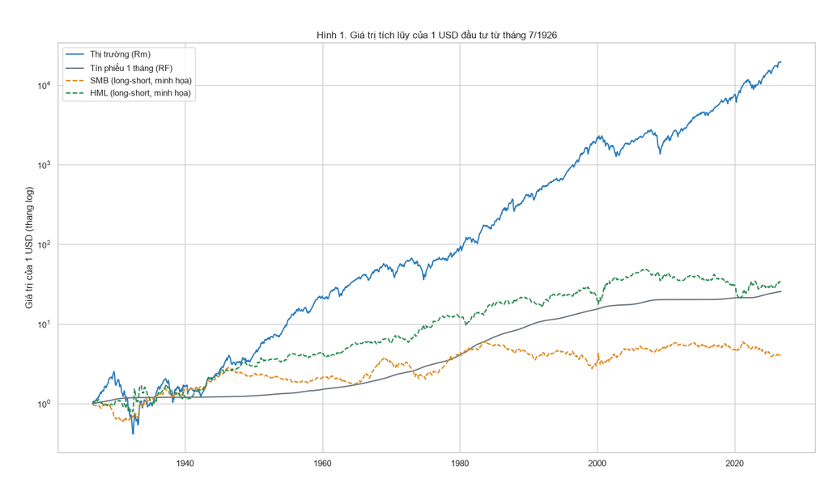

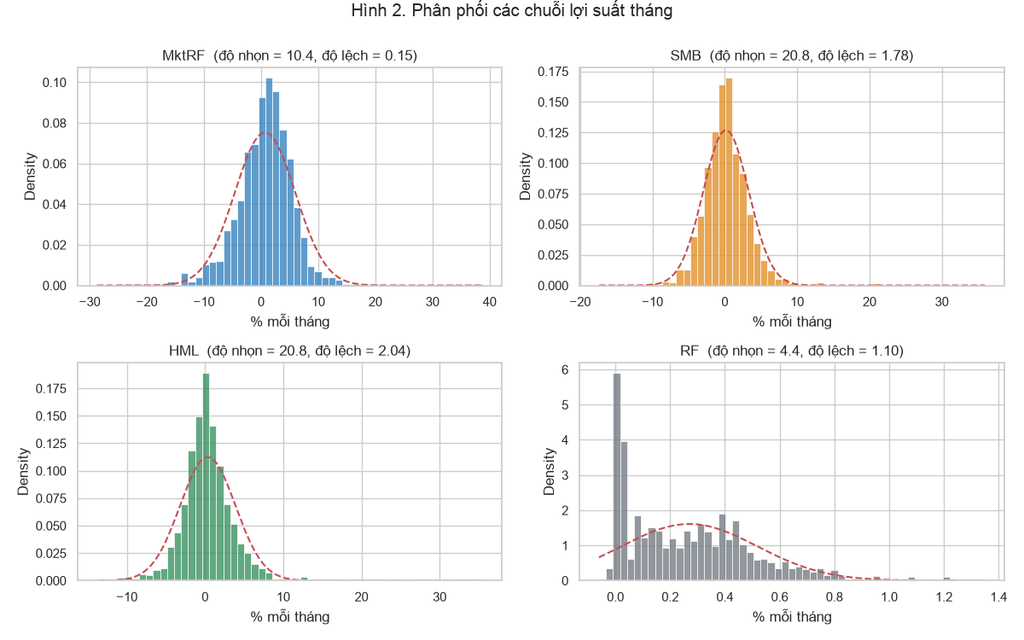

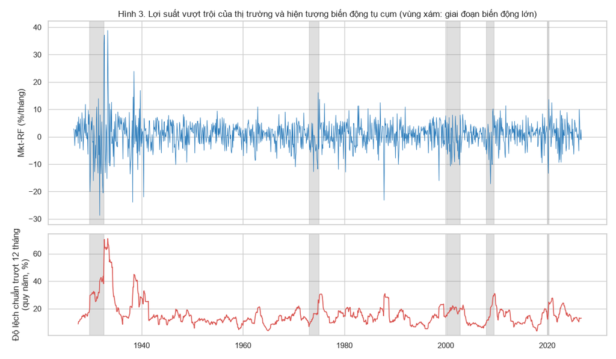

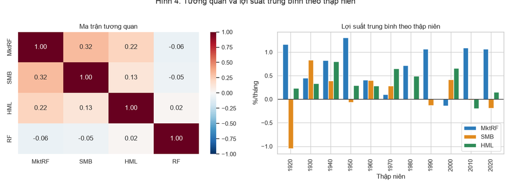

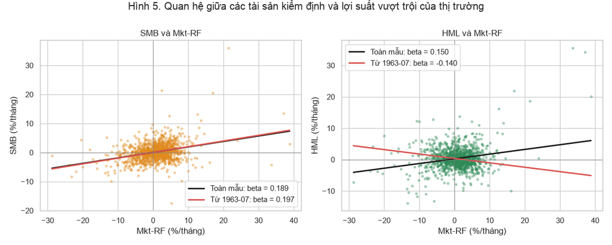

```python
# Hình 1: giá trị tích lũy của 1 USD (thang log)
fig, ax = plt.subplots(figsize=(11, 4.8))
for v, lab, c, ls in [("Rm", "Thị trường (Rm)", "#2b7bba", "-"), ("RF", "Tín phiếu 1 tháng (RF)", "#6c757d", "-"),
                      ("SMB", "SMB (long-short, minh họa)", "#e08a1e", "--"), ("HML", "HML (long-short, minh họa)", "#2e8b57", "--")]:
    ax.plot(capm.index, capm[f"cum_{v}"], label=lab, color=c, ls=ls, lw=1.6)
ax.set_yscale("log"); ax.set_ylabel("Giá trị của 1 USD (thang log)"); ax.legend(loc="upper left")
ax.set_title("Hình 1. Giá trị tích lũy của 1 USD đầu tư từ tháng 7/1926")
plt.tight_layout(); plt.show()

# Hình 2: phân phối bốn chuỗi, đường đứt đỏ là phân phối chuẩn cùng trung bình và độ lệch chuẩn
fig, ax = plt.subplots(2, 2, figsize=(12, 7.5))
for a, v, c in zip(ax.ravel(), vars_, ["#2b7bba", "#e08a1e", "#2e8b57", "#6c757d"]):
    sns.histplot(capm[v], bins=55, stat="density", color=c, ax=a)
    x = np.linspace(capm[v].min(), capm[v].max(), 300)
    a.plot(x, stats.norm.pdf(x, capm[v].mean(), capm[v].std()), "r--", lw=1.5)
    a.set_title(f"{v}  (độ nhọn = {stats.kurtosis(capm[v], fisher=False):.1f}, độ lệch = {stats.skew(capm[v]):.2f})")
    a.set_xlabel("% mỗi tháng")
plt.suptitle("Hình 2. Phân phối các chuỗi lợi suất tháng", y=1.0)
plt.tight_layout(); plt.show()

# Hình 3: Mkt-RF theo thời gian, tô bóng các giai đoạn biến động lớn, kèm biến động trượt 12 tháng
fig, ax = plt.subplots(2, 1, figsize=(12, 7), sharex=True, gridspec_kw={"height_ratios": [2, 1]})
ax[0].plot(capm.index, capm.MktRF, lw=.7, color="#2b7bba")
ax[1].plot(capm.index, capm.vol12_MktRF, lw=1.2, color="#d9534f")
for lab, (s_, e_) in crisis.items():
    for a in ax: a.axvspan(pd.Timestamp(s_), pd.Timestamp(e_), color="gray", alpha=.25)
ax[0].set_ylabel("Mkt-RF (%/tháng)"); ax[1].set_ylabel("Độ lệch chuẩn trượt 12 tháng\n(quy năm, %)")
ax[0].set_title("Hình 3. Lợi suất vượt trội của thị trường và hiện tượng biến động tụ cụm (vùng xám: giai đoạn biến động lớn)")
plt.tight_layout(); plt.show()

# Hình 4: tương quan và lợi suất trung bình theo thập niên
fig, ax = plt.subplots(1, 2, figsize=(13, 4.8))
sns.heatmap(capm[vars_].corr(), annot=True, fmt=".2f", cmap="RdBu_r", center=0, vmin=-1, vmax=1, ax=ax[0])
ax[0].set_title("Ma trận tương quan")
capm.groupby("decade")[["MktRF", "SMB", "HML"]].mean().plot.bar(ax=ax[1], width=.8, color=["#2b7bba", "#e08a1e", "#2e8b57"])
ax[1].axhline(0, color="k", lw=1); ax[1].set_xlabel("Thập niên"); ax[1].set_ylabel("%/tháng")
ax[1].set_title("Lợi suất trung bình theo thập niên")
plt.suptitle("Hình 4. Tương quan và lợi suất trung bình theo thập niên", y=1.02)
plt.tight_layout(); plt.show()

# Hình 5: SMB và HML theo Mkt-RF (mỗi chấm là một tháng)
fig, ax = plt.subplots(1, 2, figsize=(12, 4.8), sharex=True)
for a, v, c in zip(ax, ["SMB", "HML"], ["#e08a1e", "#2e8b57"]):
    a.scatter(capm.MktRF, capm[v], s=8, alpha=.35, color=c)
    for lab, d, col in [("Toàn mẫu", capm, "k"), ("Từ 1963-07", capm.loc["1963-07-01":], "#d9534f")]:
        b1, b0 = np.polyfit(d.MktRF, d[v], 1); xs = np.array([capm.MktRF.min(), capm.MktRF.max()])
        a.plot(xs, b0 + b1 * xs, color=col, lw=2, label=f"{lab}: beta = {b1:.3f}")
    a.axhline(0, color="gray", lw=.6); a.axvline(0, color="gray", lw=.6)
    a.set_xlabel("Mkt-RF (%/tháng)"); a.set_ylabel(f"{v} (%/tháng)"); a.legend(); a.set_title(f"{v} và Mkt-RF")
plt.suptitle("Hình 5. Quan hệ giữa các tài sản kiểm định và lợi suất vượt trội của thị trường", y=1.0)
plt.tight_layout(); plt.show()
```

**Nhận xét:** Hình 1 cho thấy thị trường vượt xa tín phiếu về dài hạn. Hai đường đứt của SMB và HML (danh mục mua bán đồng thời, chỉ để minh họa) tăng chậm hơn nhiều: cuối kỳ SMB gấp khoảng 4,0 lần và HML gấp khoảng 32,5 lần giá trị ban đầu, với những đoạn dao động mạnh. Hình 2 cho thấy đuôi dày rõ rệt so với đường chuẩn đứt đỏ. Hình 3 cho thấy biến động tụ cụm: các giai đoạn biến động cao tập trung quanh những giai đoạn khủng hoảng, điều này báo trước hiện tượng ARCH ở Mục 6. Hình 5 cho thấy SMB có quan hệ cùng chiều ổn định với thị trường, còn HML có độ dốc đổi dấu giữa toàn mẫu (dương) và mẫu từ 1963 (âm), một dấu hiệu sớm của beta không ổn định.

## 4. Ước lượng mô hình CAPM

Nhóm em ước lượng năm mô hình nối tiếp, từ đơn giản đến mở rộng, với sai số chuẩn Newey-West (HAC) làm chuẩn công bố. Lý do chọn HAC thay vì sai số chuẩn thường: dữ liệu chuỗi thời gian tài chính thường có phương sai sai số thay đổi và tự tương quan, và Mục 6 sẽ xác nhận điều này.

### 4.1 Thiết lập 5 mô hình thực nghiệm và bảng tổng hợp

```python
# ---------- Hàm OLS cho chuỗi thời gian: sai số chuẩn thường, HC3 và Newey-West (HAC) ----------
def nw_lag(T):
    return int(np.floor(4 * (T / 100) ** (2 / 9)))          # quy tắc chọn độ trễ thông dụng

def ols_ts(y, X, lag=None):
    y, X = np.asarray(y, float), np.asarray(X, float)
    T, k = X.shape
    XtXi = np.linalg.inv(X.T @ X)
    b = XtXi @ X.T @ y
    e = y - X @ b
    h = np.einsum("ij,jk,ik->i", X, XtXi, X)                   # đòn bẩy
    rss, tss = e @ e, ((y - y.mean()) ** 2).sum()
    s2 = rss / (T - k)
    V_ols = s2 * XtXi
    V_hc3 = XtXi @ (X.T * (e / (1 - h)) ** 2) @ X @ XtXi
    L = nw_lag(T) if lag is None else lag
    Xe = X * e[:, None]
    S = Xe.T @ Xe
    for l in range(1, L + 1):                                   # trọng số Bartlett
        G = Xe[l:].T @ Xe[:-l]
        S += (1 - l / (L + 1)) * (G + G.T)
    V_hac = XtXi @ S @ XtXi
    se = lambda V: np.sqrt(np.diag(V))
    t_hac = b / se(V_hac)
    return dict(b=b, se_ols=se(V_ols), se_hc3=se(V_hc3), se_hac=se(V_hac), V_hac=V_hac,
                t_ols=b / se(V_ols), t_hac=t_hac, p_hac=2 * stats.t.sf(np.abs(t_hac), T - k),
                p_ols=2 * stats.t.sf(np.abs(b / se(V_ols)), T - k),
                T=T, k=k, L=L, rss=rss, tss=tss, r2=1 - rss / tss,
                adj=1 - (rss / tss) * (T - 1) / (T - k), e=e, fit=X @ b, h=h, X=X, yv=y, s2=s2,
                dw=np.sum(np.diff(e) ** 2) / (e @ e))

def fit(df, y, xs, start=None, end=None):
    d = df.loc[start:end] if (start or end) else df
    d = d.dropna(subset=[y] + xs)
    X = np.column_stack([np.ones(len(d))] + [d[v].values for v in xs])
    r = ols_ts(d[y].values, X)
    r.update(names=["alpha"] + xs, dates=d.index, y_name=y)
    return r

# ---------- 5 mô hình ----------
POST = "1963-07-01"
specs = {"M1": ("SMB", ["MktRF"], None), "M2": ("HML", ["MktRF"], None),
         "M3": ("SMB", ["MktRF"], POST), "M4": ("HML", ["MktRF"], POST),
         "M5": ("HML", ["MktRF", "MktRF2"], None)}
models = {k: fit(capm, y, xs, s) for k, (y, xs, s) in specs.items()}

def star(p): return "***" if p < .01 else "**" if p < .05 else "*" if p < .1 else ""
rows = [["Biến phụ thuộc"] + [s[0] for s in specs.values()],
        ["Mẫu"] + ["1926-07 đến 2026-09" if s[2] is None else "1963-07 đến 2026-09" for s in specs.values()]]
for v in ["alpha", "MktRF", "MktRF2"]:
    r1, r2 = [v], [""]
    for k, r in models.items():
        if v in r["names"]:
            i = r["names"].index(v)
            r1.append(f"{r['b'][i]:.4f}{star(r['p_hac'][i])}"); r2.append(f"({r['se_hac'][i]:.4f})")
        else:
            r1.append(""); r2.append("")
    rows += [r1, r2]
rows += [["Số quan sát"] + [str(r["T"]) for r in models.values()],
         ["R2"] + [f"{r['r2']:.3f}" for r in models.values()],
         ["R2 hiệu chỉnh"] + [f"{r['adj']:.3f}" for r in models.values()],
         ["Durbin-Watson"] + [f"{r['dw']:.3f}" for r in models.values()],
         ["Độ trễ Newey-West"] + [str(r["L"]) for r in models.values()]]
print("Alpha tính theo %/tháng. Sai số chuẩn Newey-West (HAC) trong ngoặc.")
print("*** p<0,01  ** p<0,05  * p<0,1\n")
print(pd.DataFrame(rows[1:], columns=rows[0]).to_string(index=False))
```

Kết quả chạy Python

```
Alpha tính theo %/tháng. Sai số chuẩn Newey-West (HAC) trong ngoặc.
*** p<0,01  ** p<0,05  * p<0,1

   Biến phụ thuộc                 SMB                 HML                 SMB                 HML                 HML
              Mẫu 1926-07 đến 2026-09 1926-07 đến 2026-09 1963-07 đến 2026-09 1963-07 đến 2026-09 1926-07 đến 2026-09
            alpha              0.0319            0.2462**              0.0251           0.3758***             -0.0708
                             (0.0856)            (0.1126)            (0.1085)            (0.1375)            (0.1571)
            MktRF           0.1888***            0.1498**           0.1967***          -0.1405***            0.1240**
                             (0.0293)            (0.0745)            (0.0263)            (0.0449)            (0.0502)
           MktRF2                                                                                           0.0117***
                                                                                                             (0.0040)
      Số quan sát                1203                1203                 759                 759                1203
               R2               0.101               0.050               0.085               0.044               0.130
    R2 hiệu chỉnh               0.100               0.049               0.083               0.043               0.129
    Durbin-Watson               2.038               1.637               2.059               1.687               1.732
Độ trễ Newey-West                   6                   6                   6                   6                   6
```

**Nhận xét:** Beta của SMB theo thị trường ổn định quanh 0,19 đến 0,20 và có ý nghĩa thống kê ở mức 1% (M1, M3), còn alpha của SMB gần bằng 0 (0,032 và 0,025%/tháng, không có ý nghĩa). Với HML, alpha là 0,246%/tháng ở toàn mẫu (có ý nghĩa 5%) và 0,376%/tháng từ 1963 (có ý nghĩa 1%). Đáng chú ý nhất là beta của HML đổi dấu: +0,150 ở toàn mẫu nhưng -0,141 từ 1963. M5 cho hệ số bình phương +0,0117 có ý nghĩa 1%, và alpha của HML mất ý nghĩa (-0,071). R² chỉ từ 4,4% đến 13%, vì SMB và HML là danh mục đã được xây để tách khỏi thị trường nên thị trường giải thích được rất ít. Durbin-Watson quanh 2 chưa phản ánh hết tự tương quan, Mục 6 sẽ kiểm tra bằng các phép thử mạnh hơn.

## 5. Diễn giải kết quả và kiểm định giả thuyết

Phần này đọc các hệ số bằng đơn vị kinh tế (alpha quy năm, KTC 95% của beta), kiểm định các giả thuyết H1 đến H4, và vẽ đường SML.

### 5.1 Diễn giải alpha, beta và phần bù rủi ro thị trường

Alpha tính theo %/tháng và quy năm bằng cách nhân 12 (cách quy đổi đơn giản, không cộng dồn). Cột t(HAC) và t(OLS) đặt cạnh nhau để thấy sai số chuẩn thường bị lệch ra sao. Phần bù rủi ro thị trường được kiểm định bằng hồi quy Mkt-RF lên hằng số, dùng sai số chuẩn HAC.

```python
print("Diễn giải 4 mô hình CAPM đơn biến (sai số chuẩn Newey-West):")
print(f"{'':4s} {'tài sản':6s} {'alpha %/th':>10s} {'alpha %/năm':>11s} {'t(HAC)':>7s} {'t(OLS)':>7s} {'p(HAC)':>7s} | {'beta':>6s} {'KTC95% (HAC)':>16s} {'R2':>6s}")
for k in ["M1", "M2", "M3", "M4"]:
    r = models[k]; a0, b0 = r["b"]
    lo, hi = b0 - 1.96 * r["se_hac"][1], b0 + 1.96 * r["se_hac"][1]
    print(f"{k:4s} {specs[k][0]:6s} {a0:10.4f} {12*a0:11.2f} {r['t_hac'][0]:7.2f} {r['t_ols'][0]:7.2f} {r['p_hac'][0]:7.4f} | "
          f"{b0:6.3f} [{lo:6.3f}, {hi:6.3f}] {r['r2']:6.3f}")

# Phần bù rủi ro thị trường: hồi quy Mkt-RF lên hằng số
print("\nPhần bù rủi ro thị trường (H0: E[Mkt-RF] = 0):")
for lab, s_ in [("Toàn mẫu 1926-07 đến 2026-09", None), ("Từ 1963-07", POST)]:
    d = capm.loc[s_:] if s_ else capm
    r = ols_ts(d.MktRF.values, np.ones((len(d), 1)))
    print(f"  {lab:30s} trung bình = {r['b'][0]:.3f}%/tháng ({12*r['b'][0]:.1f}%/năm) | t(HAC) = {r['t_hac'][0]:.2f} "
          f"| p = {r['p_hac'][0]:.4f} | Sharpe năm = {r['b'][0]/d.MktRF.std()*np.sqrt(12):.2f}")

# Mô hình M5: kiểm tra phi tuyến theo Treynor-Mazuy
r5 = models["M5"]
print("\nM5 (HML, thêm bình phương Mkt-RF):")
for i, nm in enumerate(r5["names"]):
    print(f"  {nm:7s} b = {r5['b'][i]:9.5f} | SE(HAC) = {r5['se_hac'][i]:8.5f} | t = {r5['t_hac'][i]:6.2f} | p = {r5['p_hac'][i]:.4f}")
```

Kết quả chạy Python

```
Diễn giải 4 mô hình CAPM đơn biến (sai số chuẩn Newey-West):
     tài sản alpha %/th alpha %/năm  t(HAC)  t(OLS)  p(HAC) |   beta     KTC95% (HAC)     R2
M1   SMB        0.0319        0.38    0.37    0.37  0.7091 |  0.189 [ 0.131,  0.246]  0.101
M2   HML        0.2462        2.95    2.19    2.44  0.0291 |  0.150 [ 0.004,  0.296]  0.050
M3   SMB        0.0251        0.30    0.23    0.24  0.8168 |  0.197 [ 0.145,  0.248]  0.085
M4   HML        0.3758        4.51    2.73    3.53  0.0064 | -0.140 [-0.228, -0.053]  0.044

Phần bù rủi ro thị trường (H0: E[Mkt-RF] = 0):
  Toàn mẫu 1926-07 đến 2026-09   trung bình = 0.694%/tháng (8.3%/năm) | t(HAC) = 4.40 | p = 0.0000 | Sharpe năm = 0.45
  Từ 1963-07                     trung bình = 0.600%/tháng (7.2%/năm) | t(HAC) = 3.62 | p = 0.0003 | Sharpe năm = 0.47

M5 (HML, thêm bình phương Mkt-RF):
  alpha   b =  -0.07081 | SE(HAC) =  0.15711 | t =  -0.45 | p = 0.6523
  MktRF   b =   0.12396 | SE(HAC) =  0.05023 | t =   2.47 | p = 0.0137
  MktRF2  b =   0.01173 | SE(HAC) =  0.00404 | t =   2.90 | p = 0.0038
```

**Nhận xét:** H1 được ủng hộ mạnh: phần bù thị trường là 0,694%/tháng (8,3%/năm) với t(HAC) = 4,40, và 0,600%/tháng (7,2%/năm) với t = 3,62 từ 1963. Với SMB, alpha quy năm chỉ 0,38% (t = 0,37) ở toàn mẫu và 0,30% (t = 0,23) từ 1963, nên không bác bỏ H2. Với HML, alpha quy năm là 2,95% (t = 2,19; p = 0,029) ở toàn mẫu và 4,51% (t = 2,73; p = 0,006) từ 1963, nên bác bỏ H3: CAPM không giải thích được phần bù giá trị. Ở M4, t(OLS) = 3,53 lớn hơn t(HAC) = 2,73, tức sai số chuẩn thường đánh giá thấp độ bất định, đúng như đã dự báo. Hệ số bình phương ở M5 là 0,0117 (t = 2,90; p = 0,004) nên bác bỏ H6: quan hệ giữa HML và thị trường không tuyến tính.

### 5.2 Kiểm định đồng thời alpha bằng GRS và đường thị trường chứng khoán (SML)

Kiểm định GRS (Gibbons, Ross và Shanken, 1989) kiểm tra đồng thời alpha của cả hai tài sản bằng 0, có tính đến tương quan giữa các phần dư. Hình 6 đặt các tài sản lên mặt phẳng beta và lợi suất vượt trội trung bình; đường đen là SML, khoảng cách dọc từ mỗi điểm tới đường đen chính là alpha.

```python
def grs(df, assets, f="MktRF", start=None):
    """Kiểm định Gibbons-Ross-Shanken: H0 alpha cua moi tai san cung bang 0."""
    d = df.loc[start:] if start else df
    T, N = len(d), len(assets)
    Y, F = d[assets].values, d[[f]].values
    X = np.column_stack([np.ones(T), F])
    B = np.linalg.lstsq(X, Y, rcond=None)[0]
    E = Y - X @ B
    Sig = E.T @ E / T
    alpha = B[0]
    mu = F.mean(0); Om = np.atleast_2d(np.cov(F.T, bias=True))
    sr2 = float(mu @ np.linalg.solve(Om, mu))
    stat = (T - N - 1) / N * (alpha @ np.linalg.solve(Sig, alpha)) / (1 + sr2)
    return stat, stats.f.sf(stat, N, T - N - 1), alpha, T, N

print("Kiểm định GRS với 2 tài sản (SMB, HML), H0: alpha_SMB = alpha_HML = 0")
for lab, s_ in [("Toàn mẫu", None), ("Từ 1963-07", POST)]:
    st, p, al, T, N = grs(capm, ["SMB", "HML"], start=s_)
    print(f"  {lab:11s} T = {T}, N = {N}: GRS F = {st:.3f}, p = {p:.4f} | alpha = {np.round(al, 4)} (%/tháng)")

# Hình 6: SML. Trục hoành là beta, trục tung là lợi suất vượt trội trung bình
prem = capm.MktRF.mean()
fig, ax = plt.subplots(figsize=(8.5, 5.4))
xs = np.array([-0.4, 1.3]); ax.plot(xs, prem * xs, "k-", lw=1.8, label=f"SML lý thuyết: E[R]-Rf = beta x {prem:.2f}%")
pts = [("Tín phiếu (Rf)", 0, 0, "#6c757d"), ("Thị trường", 1, prem, "#2b7bba")]
for lab, b_, m_, c in pts: ax.scatter(b_, m_, s=90, color=c, zorder=3); ax.annotate(lab, (b_, m_), xytext=(6, 6), textcoords="offset points")
for k, c, mk in [("M1", "#e08a1e", "o"), ("M2", "#2e8b57", "o"), ("M3", "#e08a1e", "s"), ("M4", "#2e8b57", "s")]:
    r = models[k]; d = capm.loc[POST:] if specs[k][2] else capm; y = specs[k][0]
    ax.scatter(r["b"][1], d[y].mean(), s=80, color=c, marker=mk, zorder=3)
    ax.plot([r["b"][1]] * 2, [r["b"][1] * d.MktRF.mean(), d[y].mean()], color=c, lw=1.2, ls=":")
    ax.annotate(f"{y} ({'từ 1963' if specs[k][2] else 'toàn mẫu'})", (r["b"][1], d[y].mean()), xytext=(6, -12), textcoords="offset points", fontsize=9)
ax.axhline(0, color="gray", lw=.6); ax.set_xlabel("Beta"); ax.set_ylabel("Lợi suất vượt trội trung bình (%/tháng)")
ax.set_title("Hình 6. Đường SML và vị trí các tài sản (đường chấm: alpha)"); ax.legend(loc="upper left")
plt.tight_layout(); plt.show()
```

Kết quả chạy Python

```
Kiểm định GRS với 2 tài sản (SMB, HML), H0: alpha_SMB = alpha_HML = 0
  Toàn mẫu    T = 1203, N = 2: GRS F = 3.010, p = 0.0497 | alpha = [0.0319 0.2462] (%/tháng)
  Từ 1963-07  T = 759, N = 2: GRS F = 6.371, p = 0.0018 | alpha = [0.0251 0.3758] (%/tháng)
```

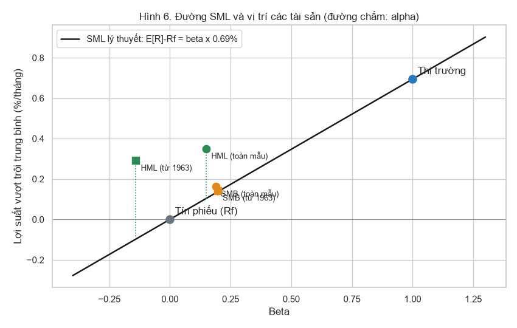

**Nhận xét:** GRS bác bỏ H4: F = 3,010 (p = 0,0497) ở toàn mẫu, tức ở ranh giới mức 5%, và F = 6,371 (p = 0,0018) từ 1963, bác bỏ rất rõ. Hình 6 cho thấy SMB nằm gần SML, còn HML nằm cao hơn SML đáng kể, nhất là ở mẫu từ 1963 khi beta của HML âm nhưng lợi suất trung bình vẫn dương. Đường SML trong Hình 6 vẽ theo phần bù toàn mẫu (0,69%/tháng), nên các điểm của mẫu từ 1963 chỉ mang tính tham khảo. Nhóm em nhắc lại GRS ở đây chỉ có N = 2 tài sản nên sức mạnh kiểm định hạn chế. Kiểm định chuẩn trong học thuật dùng hàng chục danh mục.

## 6. Chẩn đoán khuyết tật của mô hình

Mục này kiểm tra các khuyết tật có thể làm sai lệch suy diễn. Mục 6.1 gộp năm vấn đề trong một đoạn code để so sánh được cả bốn mô hình: đa cộng tuyến, phương sai sai số thay đổi, sai dạng hàm, phân phối của phần dư và tự tương quan. Mục 6.2 phân tích điểm ảnh hưởng.

### 6.1 Đa cộng tuyến, phương sai sai số thay đổi, sai dạng hàm, phân phối của phần dư và tự tương quan

Bộ kiểm định gồm: Breusch-Pagan dạng Koenker (phương sai sai số), Ramsey RESET (dạng hàm), Jarque-Bera (chuẩn tính), Durbin-Watson, Breusch-Godfrey bậc 12 và Ljung-Box bậc 12 (tự tương quan), Ljung-Box trên phần dư bình phương và ARCH-LM bậc 12 (hiệu ứng ARCH). Đa cộng tuyến chỉ có ý nghĩa ở M5 vì các mô hình còn lại chỉ có một biến giải thích.

```python
# ---- 6.1 Đa cộng tuyến: CAPM đơn biến không có đa cộng tuyến (VIF = 1). Chỉ M5 có Mkt-RF và bình phương ----
r_raw = np.corrcoef(capm.MktRF, capm.MktRF2)[0, 1]
mc = capm.MktRF - capm.MktRF.mean()
r_cen = np.corrcoef(mc, mc ** 2)[0, 1]
print(f"VIF của M5: biến gốc = {1/(1-r_raw**2):.2f} | sau khi tâm hóa = {1/(1-r_cen**2):.2f}")

# ---- 6.2 đến 6.6: bộ kiểm định chẩn đoán ----
def r2_of(y, X):
    e = y - X @ np.linalg.lstsq(X, y, rcond=None)[0]
    return 1 - (e @ e) / ((y - y.mean()) ** 2).sum()

def lb(x, T, L=12):
    x = x - x.mean()
    ac = [(x[l:] @ x[:-l]) / (x @ x) for l in range(1, L + 1)]
    Q = T * (T + 2) * sum(a ** 2 / (T - l) for l, a in enumerate(ac, 1))
    return Q, stats.chi2.sf(Q, L)

def diag(r, L=12):
    e, X, y, T, k = r["e"], r["X"], r["yv"], r["T"], r["k"]
    out = {}
    lm = T * r2_of(e ** 2, X);                    out["Breusch-Pagan (Koenker), chi2"] = (lm, stats.chi2.sf(lm, k - 1))
    f_ = r["fit"]; Xa = np.column_stack([X, f_ ** 2, f_ ** 3]); ea = y - Xa @ np.linalg.lstsq(Xa, y, rcond=None)[0]
    F = ((r["rss"] - ea @ ea) / 2) / ((ea @ ea) / (T - k - 2)); out["Ramsey RESET, F"] = (F, stats.f.sf(F, 2, T - k - 2))
    out["Jarque-Bera"] = tuple(stats.jarque_bera(e))
    out["Durbin-Watson"] = (r["dw"], np.nan)
    lags = np.column_stack([np.r_[np.zeros(l), e[:-l]] for l in range(1, L + 1)])
    lm = T * r2_of(e, np.column_stack([X, lags]));  out["Breusch-Godfrey (12), chi2"] = (lm, stats.chi2.sf(lm, L))
    out["Ljung-Box phần dư (12)"] = lb(e, T)
    out["Ljung-Box phần dư^2 (12)"] = lb(e ** 2, T)
    e2 = e ** 2; Z = np.column_stack([np.ones(T - L)] + [e2[L - l:T - l] for l in range(1, L + 1)])
    lm = (T - L) * r2_of(e2[L:], Z);               out["ARCH-LM (12)"] = (lm, stats.chi2.sf(lm, L))
    return out

dg = {k: diag(models[k]) for k in ["M1", "M2", "M3", "M4"]}
tab = pd.DataFrame({f"{k} ({specs[k][0]}{', từ 1963' if specs[k][2] else ''})":
                    {n: f"{v[0]:9.3f}" + ("" if np.isnan(v[1]) else f"  (p = {v[1]:.4f})") for n, v in d.items()}
                    for k, d in dg.items()})
print("\nKết quả kiểm định chẩn đoán (thống kê và giá trị p):")
pd.set_option("display.width", 250); print(tab.to_string())
print("\nĐộ nhọn của phần dư:", {k: round(float(stats.kurtosis(models[k]["e"], fisher=False)), 2) for k in models})
```

Kết quả chạy Python

```
VIF của M5: biến gốc = 1.02 | sau khi tâm hóa = 1.00

Kết quả kiểm định chẩn đoán (thống kê và giá trị p):
                                              M1 (SMB)                 M2 (HML)        M3 (SMB, từ 1963)        M4 (HML, từ 1963)
Breusch-Pagan (Koenker), chi2     34.003  (p = 0.0000)     73.241  (p = 0.0000)      2.748  (p = 0.0973)      5.366  (p = 0.0205)
Ramsey RESET, F                    0.733  (p = 0.4807)     94.716  (p = 0.0000)      3.643  (p = 0.0266)      0.700  (p = 0.4968)
Jarque-Bera                    11338.096  (p = 0.0000)   5969.515  (p = 0.0000)   1036.493  (p = 0.0000)    234.746  (p = 0.0000)
Durbin-Watson                                    2.038                    1.637                    2.059                    1.687
Breusch-Godfrey (12), chi2        39.014  (p = 0.0001)     59.530  (p = 0.0000)     26.594  (p = 0.0088)     23.812  (p = 0.0216)
Ljung-Box phần dư (12)            38.679  (p = 0.0001)     62.818  (p = 0.0000)     28.309  (p = 0.0050)     26.842  (p = 0.0081)
Ljung-Box phần dư^2 (12)          64.850  (p = 0.0000)    415.774  (p = 0.0000)    231.490  (p = 0.0000)    220.059  (p = 0.0000)
ARCH-LM (12)                      48.624  (p = 0.0000)    284.574  (p = 0.0000)    195.176  (p = 0.0000)     87.801  (p = 0.0000)

Độ nhọn của phần dư: {'M1': 17.79, 'M2': 13.52, 'M3': 8.67, 'M4': 5.72, 'M5': 6.38}
```

**Nhận xét:** VIF của M5 chỉ là 1,02 (gốc) và 1,00 (tâm hóa) nên không có vấn đề đa cộng tuyến. Breusch-Pagan bác bỏ phương sai đồng nhất ở M1, M2 và M4, còn M3 chỉ ở p = 0,097, vì thế dùng sai số chuẩn vững là đúng hướng. RESET bác bỏ rất mạnh ở M2 (F = 94,7), khớp với việc bình phương Mkt-RF có ý nghĩa ở M5, và bác bỏ nhẹ ở M3 (p = 0,027). Jarque-Bera bác bỏ phân phối chuẩn ở cả bốn mô hình, độ nhọn phần dư từ 5,7 đến 17,8. Dù Durbin-Watson gần 2 (từ 1,64 đến 2,06), Breusch-Godfrey và Ljung-Box bậc 12 đều bác bỏ không tự tương quan (p < 0,025). Hiệu ứng ARCH rất mạnh ở mọi mô hình (p < 0,0001). Hệ quả: hệ số OLS vẫn không chệch nhưng sai số chuẩn thường không đáng tin, nên cần HAC; và vì phân phối đuôi dày, các giá trị p chỉ đúng tiệm cận (mẫu 759 và 1.203 tháng là đủ lớn). Mô hình GARCH là hướng mở rộng để mô hình hóa trực tiếp biến động tụ cụm.

### 6.2 Điểm ảnh hưởng và đồ thị chẩn đoán

Khoảng cách Cook đo mức một quan sát làm thay đổi ước lượng, ngưỡng tham khảo là 4/T. Hình 7 vẽ bốn đồ thị chẩn đoán cho M2 (HML), gồm phần dư theo giá trị dự báo, Q-Q plot, ACF của phần dư bình phương và khoảng cách Cook.

```python
def cook(r):
    return r["e"] ** 2 / (r["k"] * r["s2"]) * r["h"] / (1 - r["h"]) ** 2

print("Quan sát có ảnh hưởng lớn (Cook's D > 4/T) và đòn bẩy (h > 2k/T):")
for k in ["M1", "M2"]:
    r = models[k]; T_, k_ = r["T"], r["k"]; cd = cook(r)
    top = pd.Series(cd, index=r["dates"]).nlargest(5)
    print(f"\n{k} ({specs[k][0]}): Cook > 4/T = {int((cd > 4/T_).sum())} | đòn bẩy > 2k/T = {int((r['h'] > 2*k_/T_).sum())} | Cook lớn nhất = {cd.max():.3f}")
    print("  5 tháng ảnh hưởng nhất:", ", ".join(f"{d:%m/%Y} ({v:.3f})" for d, v in top.items()))

# Hình 7: chẩn đoán phần dư cho mô hình M2 (HML)
r = models["M2"]; e, f_, T_ = r["e"], r["fit"], r["T"]
def acf(x, nlag=36):
    x = x - x.mean(); return np.array([(x[l:] @ x[:-l]) / (x @ x) for l in range(1, nlag + 1)])
fig, ax = plt.subplots(2, 2, figsize=(12, 8.5))
ax[0, 0].scatter(f_, e, s=8, alpha=.4, color="#2e8b57"); ax[0, 0].axhline(0, color="k", lw=1)
ax[0, 0].set(title="Phần dư theo giá trị dự báo", xlabel="Giá trị dự báo", ylabel="Phần dư")
(osm, osr), (sl, ic, _) = stats.probplot(e, dist="norm")
ax[0, 1].scatter(osm, osr, s=8, alpha=.5, color="#2e8b57"); ax[0, 1].plot(osm, sl * osm + ic, "r-")
ax[0, 1].set(title="Q-Q plot phần dư (đuôi dày)", xlabel="Phân vị lý thuyết", ylabel="Phân vị mẫu")
a2 = acf(e ** 2); band = 1.96 / np.sqrt(T_)
ax[1, 0].bar(range(1, 37), a2, color="#d9534f"); ax[1, 0].axhline(band, color="k", ls="--"); ax[1, 0].axhline(-band, color="k", ls="--")
ax[1, 0].set(title="ACF của phần dư bình phương (tụ cụm biến động)", xlabel="Độ trễ (tháng)", ylabel="Tự tương quan")
cd = cook(r); ax[1, 1].vlines(r["dates"], 0, cd, lw=.8, color="#2b7bba"); ax[1, 1].axhline(4 / T_, color="#d9534f", ls="--")
ax[1, 1].set(title="Khoảng cách Cook", xlabel="Thời gian", ylabel="Cook's D")
plt.suptitle("Hình 7. Chẩn đoán phần dư của mô hình M2 (HML theo Mkt-RF)", y=1.0)
plt.tight_layout(); plt.show()
```

Kết quả chạy Python

```
Quan sát có ảnh hưởng lớn (Cook's D > 4/T) và đòn bẩy (h > 2k/T):

M1 (SMB): Cook > 4/T = 60 | đòn bẩy > 2k/T = 77 | Cook lớn nhất = 0.796
  5 tháng ảnh hưởng nhất: 05/1933 (0.796), 07/1932 (0.225), 09/1939 (0.149), 08/1932 (0.101), 05/1932 (0.056)

M2 (HML): Cook > 4/T = 69 | đòn bẩy > 2k/T = 77 | Cook lớn nhất = 1.464
  5 tháng ảnh hưởng nhất: 08/1932 (1.464), 07/1932 (1.342), 04/1933 (0.394), 05/1933 (0.134), 09/1939 (0.134)
```

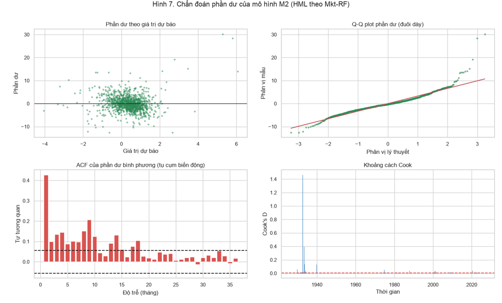

**Nhận xét:** Có 60 quan sát vượt ngưỡng Cook ở M1 và 69 ở M2. Ở M2, hai tháng 07/1932 và 08/1932 có Cook lần lượt 1,342 và 1,464, vượt cả mức 1, tức rất ảnh hưởng; đó là các tháng thị trường phục hồi mạnh sau đáy Đại suy thoái (Mkt-RF lần lượt +33,6% và +37,1%). Q-Q plot cho thấy đuôi dày, ACF của phần dư bình phương vượt dải tin cậy ở nhiều độ trễ (tụ cụm biến động). Vì các điểm ảnh hưởng này là dữ liệu thật nên nhóm em không xóa mà kiểm tra độ nhạy ở Mục 7.

## 7. Kiểm tra độ bền vững

Nhóm em kiểm tra xem kết luận về alpha và beta có thay đổi khi đổi mẫu, loại điểm đặc biệt, hiệu chỉnh giao dịch không đồng bộ (Dimson, 1979) và chia mẫu theo thời gian hay không.

### 7.1 Độ bền vững với các đặc tả và mẫu khác

Năm đặc tả cho mỗi tài sản: toàn mẫu, mẫu từ 1963, bỏ các giai đoạn biến động lớn (112 tháng), bỏ 1% tháng có |Mkt-RF| lớn nhất, và hiệu chỉnh Dimson (thêm Mkt-RF trễ 1 tháng, báo cáo tổng beta đồng thời và trễ). Giá trị t luôn dùng sai số chuẩn Newey-West.

```python
def spec_rows(asset):
    out = []
    q99 = capm.MktRF.abs().quantile(.99)
    variants = [("Toàn mẫu (CAPM chuẩn)", capm, ["MktRF"], None),
                ("Từ 1963-07", capm, ["MktRF"], POST),
                ("Bỏ các giai đoạn biến động lớn", capm[capm.crisis == 0], ["MktRF"], None),
                ("Bỏ 1% tháng có |Mkt-RF| lớn nhất", capm[capm.MktRF.abs() <= q99], ["MktRF"], None),
                ("Hiệu chỉnh Dimson (thêm Mkt-RF trễ 1 tháng)", capm, ["MktRF", "MktRF_lag1"], None)]
    for lab, d, xs, s_ in variants:
        r = fit(d, asset, xs, s_)
        if len(xs) == 1:
            beta, se_b = r["b"][1], r["se_hac"][1]
        else:                                                   # tổng beta đồng thời và trễ
            w = np.array([0, 1, 1.0]); beta = w @ r["b"]; se_b = np.sqrt(w @ r["V_hac"] @ w)
        out.append([lab, r["T"], r["b"][0], r["t_hac"][0], beta, beta / se_b, r["r2"]])
    return pd.DataFrame(out, columns=["Đặc tả / mẫu", "N", "alpha", "t(alpha)", "beta", "t(beta)", "R2"])

for asset in ["SMB", "HML"]:
    print(f"Tài sản kiểm định: {asset}  (t dùng sai số chuẩn Newey-West)")
    print(spec_rows(asset).round(3).to_string(index=False)); print()
```

Kết quả chạy Python

```
Tài sản kiểm định: SMB  (t dùng sai số chuẩn Newey-West)
                               Đặc tả / mẫu    N  alpha  t(alpha)  beta  t(beta)    R2
                      Toàn mẫu (CAPM chuẩn) 1203  0.032     0.373 0.189    6.447 0.101
                                 Từ 1963-07  759  0.025     0.232 0.197    7.479 0.085
             Bỏ các giai đoạn biến động lớn 1091 -0.035    -0.402 0.222    7.412 0.125
           Bỏ 1% tháng có |Mkt-RF| lớn nhất 1190  0.008     0.097 0.183    6.672 0.082
Hiệu chỉnh Dimson (thêm Mkt-RF trễ 1 tháng) 1202 -0.037    -0.418 0.292    5.485 0.138

Tài sản kiểm định: HML  (t dùng sai số chuẩn Newey-West)
                               Đặc tả / mẫu    N  alpha  t(alpha)   beta  t(beta)    R2
                      Toàn mẫu (CAPM chuẩn) 1203  0.246     2.185  0.150    2.011 0.050
                                 Từ 1963-07  759  0.376     2.732 -0.140   -3.131 0.044
             Bỏ các giai đoạn biến động lớn 1091  0.123     1.009  0.187    2.095 0.071
           Bỏ 1% tháng có |Mkt-RF| lớn nhất 1190  0.232     2.013  0.050    1.142 0.005
Hiệu chỉnh Dimson (thêm Mkt-RF trễ 1 tháng) 1202  0.230     1.987  0.177    2.012 0.052
```

**Nhận xét:** Với SMB kết luận rất bền: alpha luôn gần 0 (|t| < 0,45) và beta từ 0,18 đến 0,29, cao nhất ở đặc tả Dimson (0,292) cho thấy một phần phản ứng với thị trường bị trễ. Với HML, alpha dương ở mọi đặc tả nhưng độ mạnh thay đổi: 0,246 (t = 2,19) toàn mẫu, 0,376 (t = 2,73) từ 1963, 0,232 (t = 2,01) khi bỏ 1% tháng cực đoan, 0,230 (t = 1,99) với Dimson, nhưng chỉ 0,123 (t = 1,01) khi bỏ các giai đoạn biến động lớn. Nói cách khác, ý nghĩa thống kê của alpha HML ở toàn mẫu phụ thuộc vào các tháng khủng hoảng, nên nhóm em chỉ kết luận ở mức thận trọng. Beta của HML cũng nhạy: 0,150 toàn mẫu, -0,140 từ 1963, 0,187 khi bỏ giai đoạn khủng hoảng, 0,050 khi bỏ 1% tháng cực đoan.

### 7.2 Tính ổn định của beta theo thời gian: các giai đoạn con, kiểm định Chow và beta trượt

Nhóm em chia mẫu thành bốn giai đoạn con dài khoảng 25 năm, kiểm định Chow (H0: alpha và beta không đổi) và tính beta trượt 60 tháng. Chow so sánh tổng bình phương phần dư của mô hình chung với mô hình tách theo giai đoạn.

```python
# ---- Các giai đoạn con (mỗi giai đoạn khoảng 25 năm) ----
periods = [("1926-07", "1951-06"), ("1951-07", "1976-06"), ("1976-07", "2001-06"), ("2001-07", "2026-09")]
sub = {}
print("Beta theo giai đoạn con (sai số chuẩn Newey-West)")
for asset in ["SMB", "HML"]:
    for s_, e_ in periods:
        r = fit(capm, asset, ["MktRF"], s_ + "-01", e_ + "-28")
        sub[(asset, s_)] = r
        lo, hi = r["b"][1] - 1.96 * r["se_hac"][1], r["b"][1] + 1.96 * r["se_hac"][1]
        print(f"  {asset} {s_} đến {e_}: T = {r['T']:3d} | alpha = {r['b'][0]:7.3f} (t = {r['t_hac'][0]:5.2f}) | beta = {r['b'][1]:6.3f} [{lo:6.3f}, {hi:6.3f}]")

# ---- Kiểm định Chow: hệ số có đổi không? ----
def chow(asset, breaks):
    d = capm.dropna(subset=[asset]); X = np.column_stack([np.ones(len(d)), d.MktRF.values]); y = d[asset].values
    rss_p = ols_ts(y, X)["rss"]
    cuts = [d.index.get_loc(d.loc[b:].index[0]) for b in breaks]
    idx = np.split(np.arange(len(d)), cuts)
    rss_u = sum(ols_ts(y[i], X[i])["rss"] for i in idx); G = len(idx); k = 2
    F = ((rss_p - rss_u) / ((G - 1) * k)) / (rss_u / (len(d) - G * k))
    return F, stats.f.sf(F, (G - 1) * k, len(d) - G * k)

print("\nKiểm định Chow (H0: alpha và beta không đổi giữa các giai đoạn)")
for asset in ["SMB", "HML"]:
    F1, p1 = chow(asset, ["1963-07-01"]); F4, p4 = chow(asset, ["1951-07-01", "1976-07-01", "2001-07-01"])
    print(f"  {asset}: điểm gãy 1963-07  F = {F1:6.2f} (p = {p1:.4f}) | 4 giai đoạn  F = {F4:6.2f} (p = {p4:.4f})")

# ---- Beta trượt 60 tháng ----
def rolling(asset, w=60):
    y, x = capm[asset].values, capm.MktRF.values; res = []
    for t in range(w, len(capm) + 1):
        yy, xx = y[t - w:t], x[t - w:t]; b = np.cov(xx, yy, bias=True)[0, 1] / xx.var()
        a = yy.mean() - b * xx.mean(); e = yy - a - b * xx; se = np.sqrt((e @ e) / (w - 2) / ((xx - xx.mean()) ** 2).sum())
        res.append((capm.index[t - 1], b, se))
    return pd.DataFrame(res, columns=["date", "beta", "se"]).set_index("date")

roll = {a: rolling(a) for a in ["SMB", "HML"]}
for a, d in roll.items():
    print(f"\nBeta trượt 60 tháng của {a}: nhỏ nhất = {d.beta.min():.2f} ({d.beta.idxmin():%m/%Y}), lớn nhất = {d.beta.max():.2f} ({d.beta.idxmax():%m/%Y}), độ lệch chuẩn = {d.beta.std():.2f}")

# Hình 8: beta trượt
fig, ax = plt.subplots(2, 1, figsize=(12, 7), sharex=True)
for a, (nm, d), c in zip(ax, roll.items(), ["#e08a1e", "#2e8b57"]):
    a.plot(d.index, d.beta, color=c, lw=1.6); a.fill_between(d.index, d.beta - 1.96 * d.se, d.beta + 1.96 * d.se, color=c, alpha=.2)
    a.axhline(0, color="k", lw=1); a.set_ylabel(f"Beta của {nm}"); a.set_title(f"Beta trượt 60 tháng của {nm} (dải: KTC 95% theo OLS)")
plt.suptitle("Hình 8. Beta không ổn định theo thời gian", y=1.0)
plt.tight_layout(); plt.show()

# Hình 9: beta theo giai đoạn con
fig, ax = plt.subplots(1, 2, figsize=(12, 4.6), sharey=True)
for a, asset, c in zip(ax, ["SMB", "HML"], ["#e08a1e", "#2e8b57"]):
    bs = [sub[(asset, s_)]["b"][1] for s_, _ in periods]; es = [1.96 * sub[(asset, s_)]["se_hac"][1] for s_, _ in periods]
    a.errorbar([f"{s_[:4]}-{e_[:4]}" for s_, e_ in periods], bs, yerr=es, fmt="o", capsize=5, color=c)
    a.axhline(0, color="k", lw=1); a.set_title(f"Beta của {asset} theo giai đoạn"); a.set_ylabel("Beta (KTC 95%, HAC)")
plt.suptitle("Hình 9. Beta theo bốn giai đoạn con", y=1.02)
plt.tight_layout(); plt.show()
```

Kết quả chạy Python

```
Beta theo giai đoạn con (sai số chuẩn Newey-West)
  SMB 1926-07 đến 1951-06: T = 299 | alpha =   0.187 (t =  0.96) | beta =  0.207 [ 0.103,  0.311]
  SMB 1951-07 đến 1976-06: T = 299 | alpha =  -0.041 (t = -0.26) | beta =  0.189 [ 0.084,  0.294]
  SMB 1976-07 đến 2001-06: T = 299 | alpha =   0.064 (t =  0.35) | beta =  0.148 [ 0.059,  0.238]
  SMB 2001-07 đến 2026-09: T = 302 | alpha =  -0.061 (t = -0.44) | beta =  0.180 [ 0.121,  0.238]
  HML 1926-07 đến 1951-06: T = 299 | alpha =   0.217 (t =  0.88) | beta =  0.422 [ 0.246,  0.599]
  HML 1951-07 đến 1976-06: T = 299 | alpha =   0.439 (t =  3.05) | beta = -0.058 [-0.168,  0.052]
  HML 1976-07 đến 2001-06: T = 299 | alpha =   0.648 (t =  3.16) | beta = -0.349 [-0.456, -0.243]
  HML 2001-07 đến 2026-09: T = 302 | alpha =   0.024 (t =  0.11) | beta =  0.051 [-0.073,  0.174]

Kiểm định Chow (H0: alpha và beta không đổi giữa các giai đoạn)
  SMB: điểm gãy 1963-07  F =   0.09 (p = 0.9102) | 4 giai đoạn  F =   0.58 (p = 0.7447)
  HML: điểm gãy 1963-07  F = 113.34 (p = 0.0000) | 4 giai đoạn  F =  53.63 (p = 0.0000)

Beta trượt 60 tháng của SMB: nhỏ nhất = -0.29 (01/1957), lớn nhất = 0.50 (12/1969), độ lệch chuẩn = 0.15

Beta trượt 60 tháng của HML: nhỏ nhất = -0.55 (04/2001), lớn nhất = 0.74 (06/1937), độ lệch chuẩn = 0.28
```

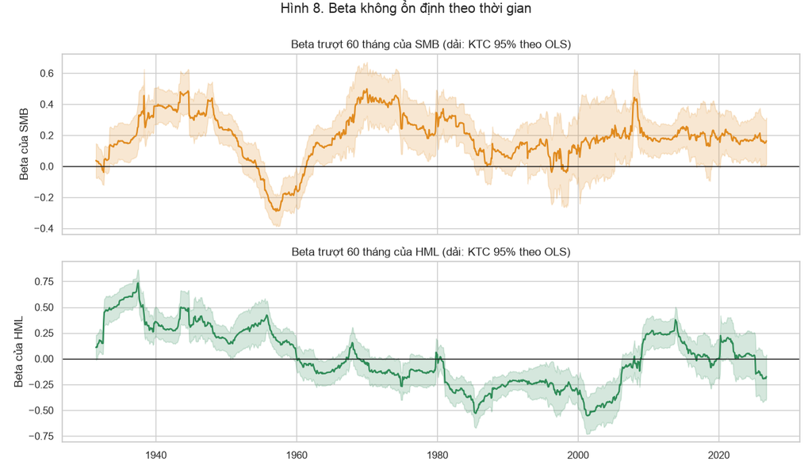

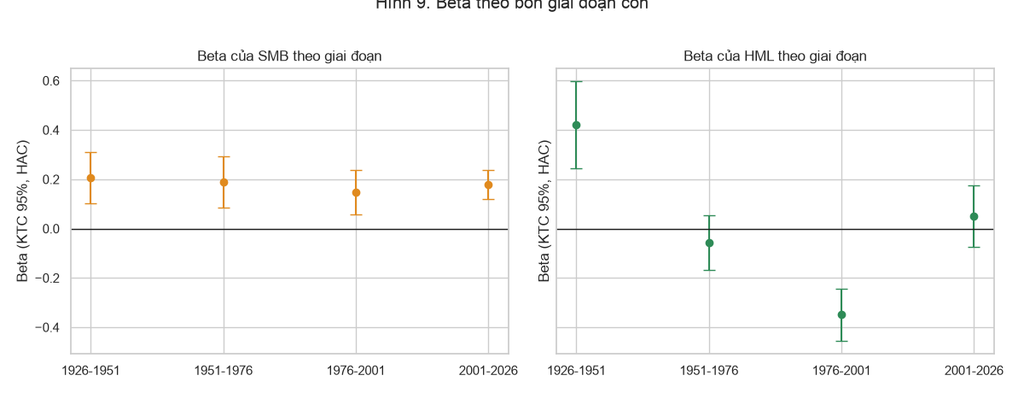

**Nhận xét:** Beta của SMB ổn định (0,15 đến 0,21 ở cả bốn giai đoạn) và Chow không bác bỏ (p = 0,91 với điểm gãy 1963; p = 0,74 với bốn giai đoạn). Beta của HML thì không: 0,422 (1926-1951), -0,058 (1951-1976), -0,349 (1976-2001) và 0,051 (2001-2026); Chow bác bỏ rất mạnh (p < 0,0001 cả hai phép thử). Alpha của HML tập trung ở 1951-2001: 0,439%/tháng (t = 3,05) và 0,648%/tháng (t = 3,16), rồi biến mất ở giai đoạn cuối (0,024; t = 0,11). Beta trượt của HML dao động từ -0,55 (04/2001) đến 0,74 (06/1937) với độ lệch chuẩn 0,28, trong khi SMB chỉ từ -0,29 đến 0,50 (độ lệch chuẩn 0,15). Vì vậy một con số beta duy nhất cho HML trên toàn mẫu không có nhiều ý nghĩa; đây chính là vấn đề beta không ổn định mà Mục 8 bàn thêm.

## 8. Các vấn đề trong kiểm định CAPM và hướng mở rộng

Các kết quả trên phản ánh những vấn đề nổi tiếng trong kiểm định CAPM mà nhóm em tổng hợp lại:

- **Danh mục thị trường không quan sát được (Roll, 1977).** CAPM nói về danh mục gồm mọi tài sản, còn Mkt-RF chỉ gồm cổ phiếu Mỹ. Vì vậy theo Roll, mô hình về nguyên tắc không kiểm định được, chỉ kiểm định được tính hữu hiệu của danh mục đại diện.
- **Beta không ổn định.** Mục 7 cho thấy beta của HML đổi dấu qua các giai đoạn. Điều này làm giả định "beta cố định" của hồi quy chuỗi thời gian đơn giản bị yếu đi.
- **Sai số đo lường của beta (errors-in-variables).** Trong hồi quy hai bước kiểu Fama-MacBeth (1973), beta ước lượng ở bước một có sai số nên làm lệch độ dốc của SML ở bước hai; người ta xử lý bằng cách nhóm cổ phiếu thành danh mục. Bài này không chạy hồi quy chéo vì chỉ có hai tài sản.
- **Giao dịch không đồng bộ.** Cổ phiếu nhỏ giao dịch thưa làm beta bị ước lượng thấp; Dimson (1979) thêm các độ trễ của lợi suất thị trường. Mục 7.1 đã làm với một độ trễ.
- **Dị thường quy mô và giá trị.** Fama và French (1992) cho thấy beta không giải thích được lợi suất theo chiều ngang, trong khi quy mô và tỷ số giá trị sổ sách trên thị trường thì có. Kết quả alpha của HML trong bài này đi cùng hướng đó.
- **Mô hình ba nhân tố Fama-French (1993).** Thêm hai nhân tố SMB và HML vào CAPM: R<sub>i</sub> − R<sub>f</sub> = a + b × (Mkt−RF) + s × SMB + h × HML + e. Để chạy mô hình này cần lợi suất của các danh mục kiểm định (ví dụ 25 danh mục theo quy mô và giá trị); file hiện tại không có, nên nhóm em chưa ước lượng. Việc dùng chính SMB và HML làm biến phụ thuộc sẽ gây trùng lặp.
- **Lý thuyết kinh doanh chênh lệch giá (APT, Ross, 1976).** Cho phép nhiều nhân tố rủi ro thay vì một. Việc ước lượng APT cần thêm các nhân tố vĩ mô (lạm phát, sản lượng công nghiệp, lãi suất...) không có trong dữ liệu này.
- **Phương sai thay đổi và đuôi dày.** Mục 6 cho thấy hiệu ứng ARCH rất mạnh. HAC sửa sai số chuẩn nhưng không làm ước lượng hiệu quả hơn, và GARCH là hướng nâng cao.

## 9. Khung báo cáo kết quả và hàm ý

### 9.1 Mẫu đoạn báo cáo kết quả

"Nhóm em dùng 1.203 quan sát tháng của bộ dữ liệu Fama-French (07/1926 đến 09/2026). Phần bù rủi ro thị trường là 0,694%/tháng (8,3%/năm), có ý nghĩa thống kê (t = 4,40, sai số chuẩn Newey-West). Hồi quy SMB lên Mkt-RF cho beta bằng 0,189 (KTC 95%: 0,131 đến 0,246) và alpha bằng 0,032%/tháng, không khác 0 một cách có ý nghĩa (t = 0,37). Với HML, alpha bằng 0,246%/tháng (2,95%/năm; t = 2,19), tăng lên 0,376%/tháng (t = 2,73) khi chỉ dùng mẫu từ 07/1963. Kiểm định GRS bác bỏ việc cả hai alpha cùng bằng 0 (F = 3,010, p = 0,0497 toàn mẫu; F = 6,371, p = 0,0018 từ 1963). Beta của HML không ổn định (kiểm định Chow p < 0,0001) và alpha của HML mất ý nghĩa khi bỏ các giai đoạn biến động lớn (t = 1,01), nên nhóm em kết luận thận trọng rằng CAPM không giải thích đầy đủ phần bù giá trị, và kết luận này nhạy với các tháng khủng hoảng."

### 9.2 Hàm ý

- Beta thị trường một mình không đủ để giải thích lợi suất của danh mục theo giá trị, phù hợp với lập luận ủng hộ mô hình đa nhân tố.
- Khi ước lượng beta bằng dữ liệu lịch sử, nên dùng cửa sổ trượt hoặc kiểm tra tính ổn định, không nên coi một con số beta là hằng số.
- Khi suy diễn với dữ liệu tài chính tần suất tháng, nên dùng sai số chuẩn vững với phương sai thay đổi và tự tương quan.

## 10. Lưu ý của nhóm

- **Nói rõ giới hạn dữ liệu.** Bài này dùng SMB và HML làm tài sản kiểm định, không phải cổ phiếu riêng lẻ. Khi được hỏi "beta của cổ phiếu X", phải trả lời rằng cần dữ liệu lợi suất của X và dùng đúng quy trình ở Mục 4.
- **Phân biệt lợi suất thường và lợi suất vượt trội.** Mkt-RF và SMB, HML đã là lợi suất vượt trội; riêng một cổ phiếu thì phải trừ `RF` trước khi hồi quy.
- **Đơn vị.** Mọi giá trị trong file là phần trăm, không phải số thập phân. Quy năm alpha bằng nhân 12 chỉ là xấp xỉ.
- **Không xóa ngoại lai tài chính.** Các tháng khủng hoảng là bản chất của rủi ro; chỉ nên kiểm tra độ nhạy.
- **Không báo cáo sai số chuẩn thường cho chuỗi thời gian.** Dùng Newey-West hoặc HC3 và nêu độ trễ.
- **Chuẩn bị trả lời.** Vì sao R² thấp? (SMB và HML là danh mục long-short được xây để ít phụ thuộc thị trường.) Vì sao beta của HML đổi dấu? (Mục 7.2.) Vì sao GRS ở toàn mẫu chỉ ở ranh giới? (N = 2 và kết quả nhạy với giai đoạn khủng hoảng.)
- **Code R chưa được chạy trong môi trường tạo file.** Nhóm nên chạy thử và đối chiếu với kết quả Python trước khi nộp.

## 11. Phụ lục và tài liệu tham khảo

### 11.1 Các file đi kèm

- `capm_clean_monthly.csv`: dữ liệu tháng đã làm sạch, 1.203 dòng và 22 cột.
- `capm_analysis.py` và `capm_analysis.R`: kịch bản chạy độc lập từ đầu đến cuối.

### 11.2 Bảng kiểm tra chất lượng bài nộp

- Đã nêu rõ tài sản kiểm định và giới hạn của dữ liệu.
- Đã kiểm tra thiếu, trùng, liên tục và đối chiếu với khối năm.
- Đã dùng sai số chuẩn Newey-West và nêu độ trễ.
- Đã chạy đủ chẩn đoán (BP, RESET, JB, DW, BG, Ljung-Box, ARCH).
- Đã kiểm tra độ bền vững và tính ổn định của beta (Chow, beta trượt).
- Đã nêu các hạn chế (Roll, beta không ổn định, N = 2 trong GRS).

### 11.3 Tài liệu tham khảo

- Black, F., Jensen, M. C., & Scholes, M. (1972). The Capital Asset Pricing Model: Some empirical tests. Trong M. C. Jensen (Ed.), *Studies in the Theory of Capital Markets*. Praeger.
- Dimson, E. (1979). Risk measurement when shares are subject to infrequent trading. *Journal of Financial Economics*, 7(2), 197-226.
- Fama, E. F., & French, K. R. (1992). The cross-section of expected stock returns. *Journal of Finance*, 47(2), 427-465.
- Fama, E. F., & French, K. R. (1993). Common risk factors in the returns on stocks and bonds. *Journal of Financial Economics*, 33(1), 3-56.
- Fama, E. F., & French, K. R. (2004). The Capital Asset Pricing Model: Theory and evidence. *Journal of Economic Perspectives*, 18(3), 25-46.
- Fama, E. F., & MacBeth, J. D. (1973). Risk, return, and equilibrium: Empirical tests. *Journal of Political Economy*, 81(3), 607-636.
- Gibbons, M. R., Ross, S. A., & Shanken, J. (1989). A test of the efficiency of a given portfolio. *Econometrica*, 57(5), 1121-1152.
- Lintner, J. (1965). The valuation of risk assets and the selection of risky investments in stock portfolios and capital budgets. *Review of Economics and Statistics*, 47(1), 13-37.
- Mossin, J. (1966). Equilibrium in a capital asset market. *Econometrica*, 34(4), 768-783.
- Newey, W. K., & West, K. D. (1987). A simple, positive semi-definite, heteroskedasticity and autocorrelation consistent covariance matrix. *Econometrica*, 55(3), 703-708.
- Roll, R. (1977). A critique of the asset pricing theory's tests. *Journal of Financial Economics*, 4(2), 129-176.
- Ross, S. A. (1976). The arbitrage theory of capital asset pricing. *Journal of Economic Theory*, 13(3), 341-360.
- Sharpe, W. F. (1964). Capital asset prices: A theory of market equilibrium under conditions of risk. *Journal of Finance*, 19(3), 425-442.

Dữ liệu: Kenneth R. French Data Library, Fama/French 3 Factors (file F-F_Research_Data_Factors), tạo từ cơ sở dữ liệu CRSP 202609.